# R Notebook

```r
library(modelr)
```

whatgoodness of fit measure of fit -adjr”, AIC, BIC, parsimonious measures test train ssplit 90:1-

K-Fold CV?- yes to prevent overfitting model or models? red/white separately

white wine first

```r
n_data_white <- nrow(white_wine)
test_prop <- 0.1

test_index_white <- sample(1:n_data_white, size = n_data_white*test_prop)
test_white <- slice(white_wine, test_index_white)
train_white <- slice(white_wine, -test_index_white)
```

# explore the data # what does 1 row represent - one row represents a wine with tech measurement and sumamrised average of quality rating # what variab;es do we have, real- world process etc # what influences targert(wine quality)

desnisty, alcoghol, extreme values of acidity # what transformations might be useful? log transformation opportunities for positively skewaed data

```r
 skim(train_white)
```

```
── Data Summary ────────────────────────
                           Values
Name                       train_white
Number of rows             4409
Number of columns          14
_______________________
Column type frequency:
  character                1
  numeric                  13
________________________
Group variables            None
```

|  | skim_variable | n_missing | complete_rate | min | max | empty | n_unique | whitespace |
| --- | --- | --- | --- | --- | --- | --- | --- | --- |
| 1 | region | 0 | 1 | 3 | 9 | 0 | 5 | 0 |

|  | skim_variable | n_missing | complete_rate | mean | sd | p0 | p25 | p50 | p75 | p100 | hist |
| --- | --- | --- | --- | --- | --- | --- | --- | --- | --- | --- | --- |
| 1 | wine_id | 0 | 1 | 2428.4567929 | 1.415134e+03 | 1.00000 | 1202.00000 | 2414.00000 | 3656.00000 | 4898.00000 | ▇▇▇▇▇ |
| 2 | fixed_acidity | 0 | 1 | 6.8637333 | 8.388806e-01 | 3.80000 | 6.30000 | 6.80000 | 7.30000 | 11.80000 | ▁▇▅▁▁ |
| 3 | volatile_acidity | 0 | 1 | 0.2783125 | 1.010067e-01 | 0.08000 | 0.21000 | 0.26000 | 0.32000 | 1.10000 | ▇▅▁▁▁ |
| 4 | citric_acid | 0 | 1 | 0.3349354 | 1.220154e-01 | 0.00000 | 0.27000 | 0.32000 | 0.39000 | 1.66000 | ▇▆▁▁▁ |
| 5 | residual_sugar | 0 | 1 | 6.4110796 | 5.108606e+00 | 0.60000 | 1.70000 | 5.20000 | 9.90000 | 65.80000 | ▇▁▁▁▁ |
| 6 | chlorides | 0 | 1 | 0.0458562 | 2.193611e-02 | 0.00900 | 0.03600 | 0.04300 | 0.05000 | 0.34600 | ▇▁▁▁▁ |
| 7 | free_sulfur_dioxide | 0 | 1 | 35.3975958 | 1.701374e+01 | 2.00000 | 23.00000 | 34.00000 | 46.00000 | 289.00000 | ▇▁▁▁▁ |
| 8 | total_sulfur_dioxide | 0 | 1 | 138.5898163 | 4.238514e+01 | 9.00000 | 108.00000 | 135.00000 | 167.00000 | 440.00000 | ▂▇▂▁▁ |
| 9 | density | 0 | 1 | 0.9940516 | 3.005428e-03 | 0.98711 | 0.99174 | 0.99378 | 0.99615 | 1.03898 | ▇▂▁▁▁ |
| 10 | p_h | 0 | 1 | 3.1887321 | 1.517308e-01 | 2.72000 | 3.09000 | 3.18000 | 3.28000 | 3.82000 | ▁▇▇▂▁ |

[output cut: 3 more lines]

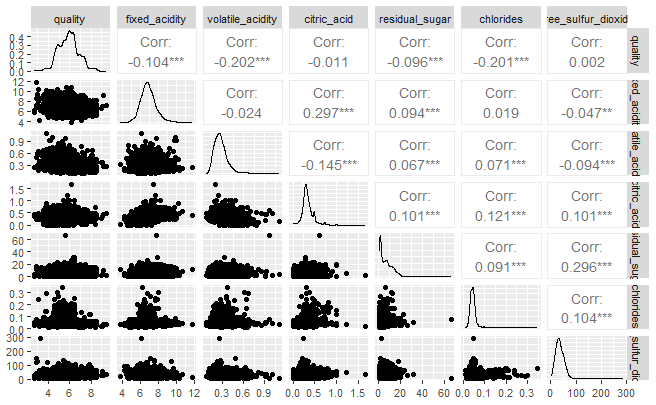

```r
train_white %>%
  select(quality, 2:7) %>%
  ggpairs(progress = FALSE)
```

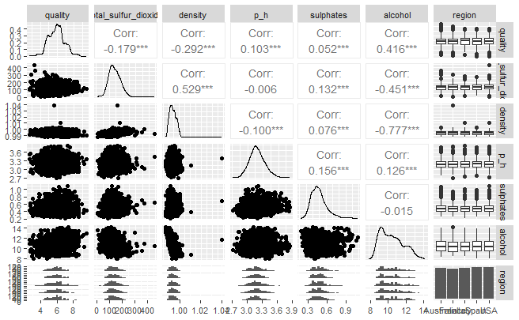

```r
train_white %>%
  select(quality, 8:14) %>%
  ggpairs(progress = FALSE)
```

let#s do transforamtions log of 1+ variable

```r
train_white_fe <- train_white %>%
  mutate(across(where(is.numeric),
                .fns = ~ log(1 + .x),
                .names = "log_{.col}")) %>% # log transformed everything and added new columns with log in the name
  mutate(chlorides_diff_to_mean = chlorides - mean(chlorides), # shifted distribution to center it around 0
          .after = chlorides) %>%
  mutate(chloride_abs_diff_to_mean = abs(chlorides_diff_to_mean), .after = chlorides_diff_to_mean)
```

[figure not shown]

```r
summary(mod1)
```

[output not shown]

```
Call:
lm(formula = quality ~ alcohol, data = train_white_fe)

Residuals:
    Min      1Q  Median      3Q     Max
-3.5184 -0.5651 -0.0183  0.5415  3.2832

Coefficients:
            Estimate Std. Error t value Pr(>|t|)
(Intercept)  2.57465    0.11031   23.34   <2e-16 ***
alcohol      0.31656    0.01043   30.36   <2e-16 ***
---
Signif. codes:  0 ‘***’ 0.001 ‘**’ 0.01 ‘*’ 0.05 ‘.’ 0.1 ‘ ’ 1

Residual standard error: 0.8509 on 4407 degrees of freedom
Multiple R-squared:  0.173, Adjusted R-squared:  0.1728
F-statistic:   922 on 1 and 4407 DF,  p-value: < 2.2e-16
```

for every 3% of alcohol we get 1 point increase in quality. explaining about 17% of the variation.

from the second stage we’re doing it on residuals as from now on, we’re interested only in finding out what helps us explain the difference in resuduals

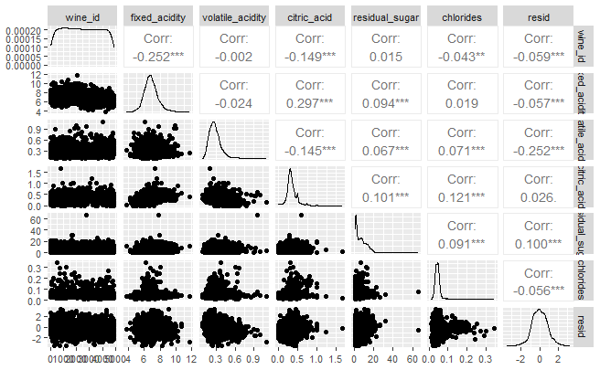

```r
 train_white_fe %>%
  add_predictions(mod1) %>%
  add_residuals(mod1) %>%
  select(1:6, resid) %>%
  ggpairs(progress = FALSE)
```

```r
summary(mod1)
```

```
Call:
lm(formula = quality ~ alcohol, data = train_white_fe)

Residuals:
    Min      1Q  Median      3Q     Max
-3.5184 -0.5651 -0.0183  0.5415  3.2832

Coefficients:
            Estimate Std. Error t value Pr(>|t|)
(Intercept)  2.57465    0.11031   23.34   <2e-16 ***
alcohol      0.31656    0.01043   30.36   <2e-16 ***
---
Signif. codes:  0 ‘***’ 0.001 ‘**’ 0.01 ‘*’ 0.05 ‘.’ 0.1 ‘ ’ 1

Residual standard error: 0.8509 on 4407 degrees of freedom
Multiple R-squared:  0.173, Adjusted R-squared:  0.1728
F-statistic:   922 on 1 and 4407 DF,  p-value: < 2.2e-16
```

```r
mod2 <- lm(quality ~ alcohol + volatile_acidity, data = train_white_fe)
summary(mod2)
```

```
Call:
lm(formula = quality ~ alcohol + volatile_acidity, data = train_white_fe)

Residuals:
    Min      1Q  Median      3Q     Max
-3.6141 -0.5486 -0.0144  0.5191  3.2667

Coefficients:
                 Estimate Std. Error t value Pr(>|t|)
(Intercept)       3.04619    0.11014   27.66   <2e-16 ***
alcohol           0.32823    0.01011   32.47   <2e-16 ***
volatile_acidity -2.13494    0.12305  -17.35   <2e-16 ***
---
Signif. codes:  0 ‘***’ 0.001 ‘**’ 0.01 ‘*’ 0.05 ‘.’ 0.1 ‘ ’ 1

Residual standard error: 0.8234 on 4406 degrees of freedom
Multiple R-squared:  0.2259,    Adjusted R-squared:  0.2256
F-statistic: 642.9 on 2 and 4406 DF,  p-value: < 2.2e-16
```

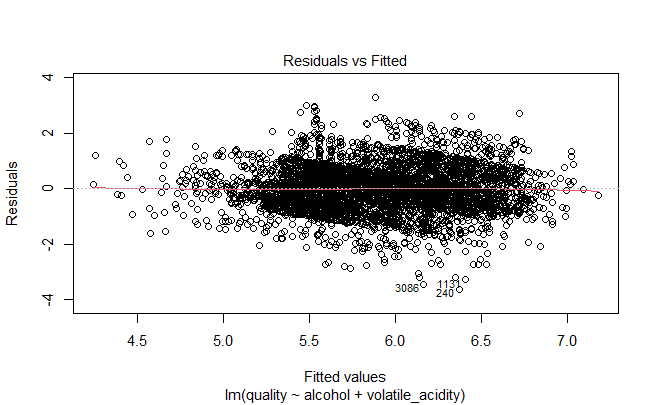

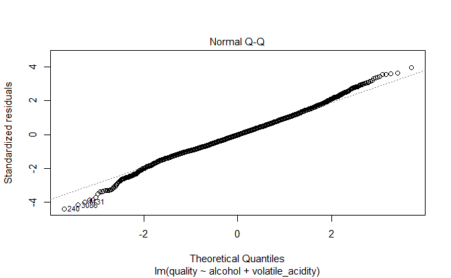

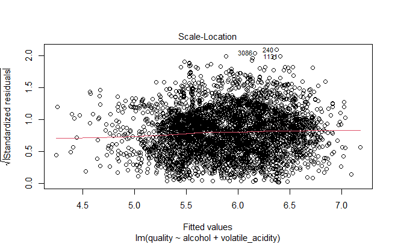

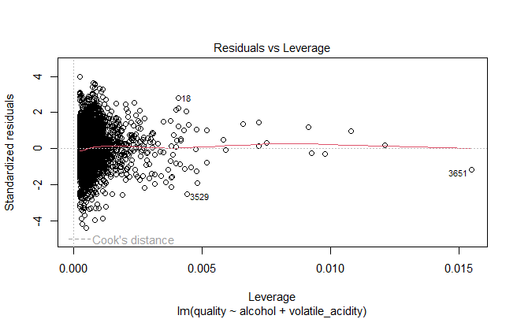

```r
plot(mod2)
```

```r
white_wine_cv_10_fold <- trainControl(method = "cv", # cross-validation
                           number = 10, # 10-fold
                           savePredictions = TRUE) # save all predictions

model_ww10fold <- train(quality ~ .,
               data = train_white,
               trControl = white_wine_cv_10_fold,
               method = 'lm')
```